# R Notebook

# 1) Get data

- http://archive.ics.uci.edu/ml/datasets/Energy+efficiency#

```r
library(readxl)
library(dplyr)
```

```r
library(ggplot2)
library(tidyverse)
library(modelr)
```

```r
building_data <- read_excel("ENB2012_data.xlsx")
building_data
```

| X1 | X2 | X3 | X4 | X5 | X6 | X7 | X8 | Y1 | Y2 |
| --- | --- | --- | --- | --- | --- | --- | --- | --- | --- |
| 0.98 | 514.5 | 294.0 | 110.25 | 7.0 | 2 | 0.00 | 0 | 15.550 | 21.33 |
| 0.98 | 514.5 | 294.0 | 110.25 | 7.0 | 3 | 0.00 | 0 | 15.550 | 21.33 |
| 0.98 | 514.5 | 294.0 | 110.25 | 7.0 | 4 | 0.00 | 0 | 15.550 | 21.33 |
| 0.98 | 514.5 | 294.0 | 110.25 | 7.0 | 5 | 0.00 | 0 | 15.550 | 21.33 |
| 0.90 | 563.5 | 318.5 | 122.50 | 7.0 | 2 | 0.00 | 0 | 20.840 | 28.28 |
| 0.90 | 563.5 | 318.5 | 122.50 | 7.0 | 3 | 0.00 | 0 | 21.460 | 25.38 |
| 0.90 | 563.5 | 318.5 | 122.50 | 7.0 | 4 | 0.00 | 0 | 20.710 | 25.16 |
| 0.90 | 563.5 | 318.5 | 122.50 | 7.0 | 5 | 0.00 | 0 | 19.680 | 29.60 |
| 0.86 | 588.0 | 294.0 | 147.00 | 7.0 | 2 | 0.00 | 0 | 19.500 | 27.30 |
| 0.86 | 588.0 | 294.0 | 147.00 | 7.0 | 3 | 0.00 | 0 | 19.950 | 21.97 |

[output cut: 758 more lines]

- About the data: X1 Relative Compactness X2 Surface Area X3 Wall Area X4 Roof Area X5 Overall Height X6 Orientation X7 Glazing Area X8 Glazing Area Distribution y1 Heating Load y2 Cooling Load

# 2)Separate to train and test set.

- 80% train, rest 20% test.

```r
b_train <- building_data %>%
  sample_frac(.8)

b_test <- setdiff(building_data, b_train)
```

# 3) Make a linear model to predict Heating Load

- Linear model according to the eight attributes
- Two boxplots visualize and compare data(black) and model(red)

```r
mod_1 <- lm(Y1 ~ X1 + X2 + X3 + X4 + X5 + X6 + X7 + X8, data = b_train)

grid_1 <- b_train %>%
  #data_grid(b_train, X6) %>%
  add_predictions(mod_1, "pred_Y1")
```

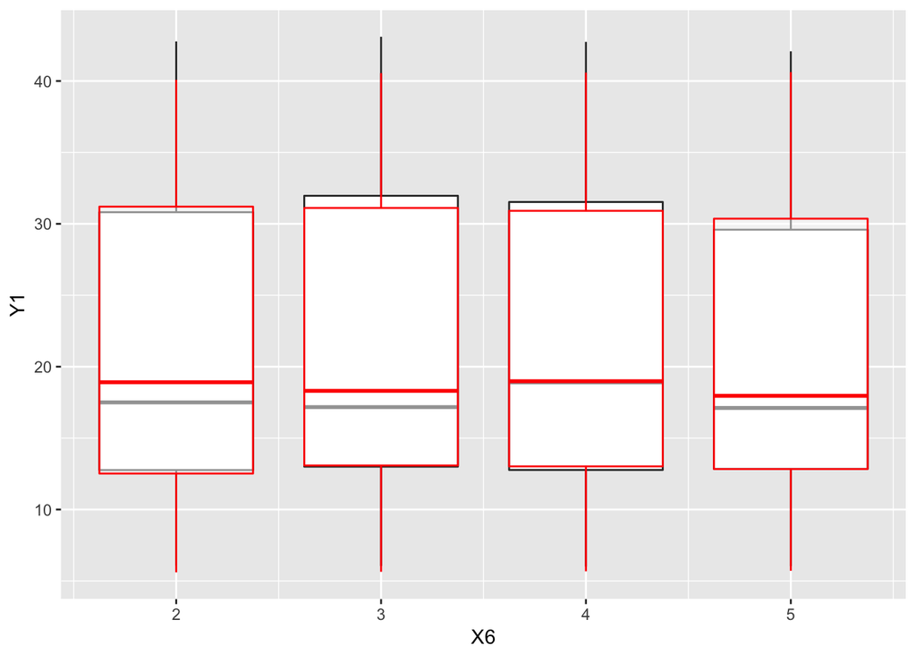

```r
ggplot(b_train, aes(x = X6, y = Y1, group = cut_interval(X6,4))) +
  geom_boxplot() +
  scale_x_continuous(breaks=c(1,2,3,4,5)) +
  geom_boxplot(data = grid_1, aes(x = X6, y = pred_Y1), colour = "red", alpha = 0.5)
```

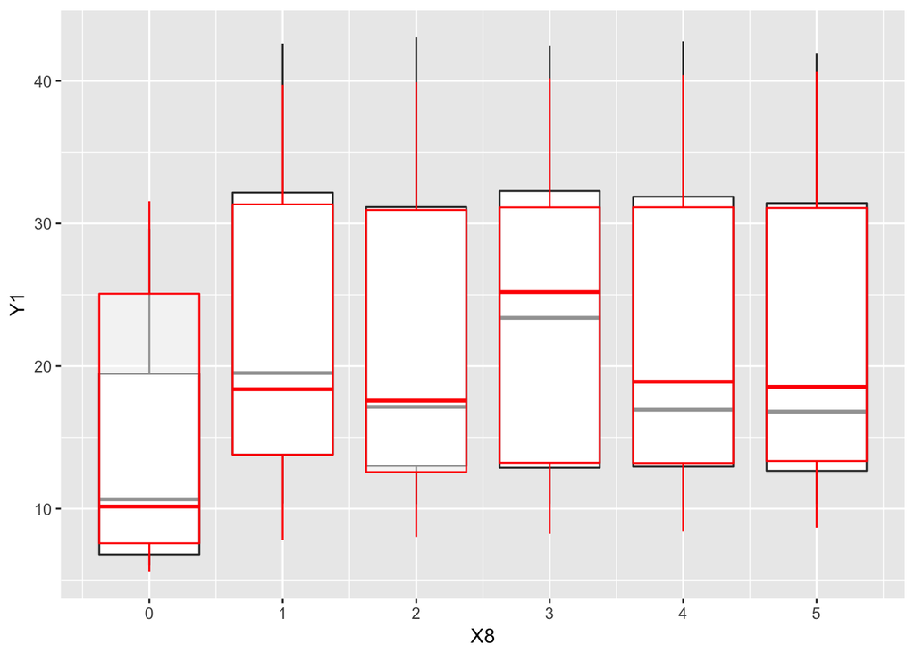

```r
ggplot(b_train, aes(x = X8, y = Y1, group = cut_interval(X8,6))) +
  geom_boxplot() +
  scale_x_continuous(breaks=c(0,1,2,3,4,5,6)) +
  geom_boxplot(data = grid_1, aes(x = X8, y = pred_Y1, group = cut_interval(X8,6)), colour = "red", alpha = 0.5)
```

# 4) Evaluate:

- What can you tell about the model? How reliable it is?
- Which parameters are statistically significant?
- Which parameters are the most influential?

```r
summary(mod_1)
```

```
##
## Call:
## lm(formula = Y1 ~ X1 + X2 + X3 + X4 + X5 + X6 + X7 + X8, data = b_train)
##
## Residuals:
##     Min      1Q  Median      3Q     Max
## -9.2557 -1.3478 -0.0919  1.3161  7.4560
##
## Coefficients: (1 not defined because of singularities)
##               Estimate Std. Error t value Pr(>|t|)
## (Intercept)  82.337849  21.245150   3.876 0.000118 ***
## X1          -65.497565  11.563028  -5.664 2.28e-08 ***
## X2           -0.084015   0.019060  -4.408 1.23e-05 ***
## X3            0.056549   0.007476   7.564 1.46e-13 ***
## X4                  NA         NA      NA       NA
## X5            4.411017   0.376760  11.708  < 2e-16 ***
## X6            0.036830   0.104395   0.353 0.724363
## X7           19.882442   0.900243  22.086  < 2e-16 ***
## X8            0.214952   0.076680   2.803 0.005222 **
## ---
## Signif. codes:  0 '***' 0.001 '**' 0.01 '*' 0.05 '.' 0.1 ' ' 1
##
## Residual standard error: 2.887 on 606 degrees of freedom
## Multiple R-squared:  0.9203, Adjusted R-squared:  0.9194
## F-statistic: 999.4 on 7 and 606 DF,  p-value: < 2.2e-16
```

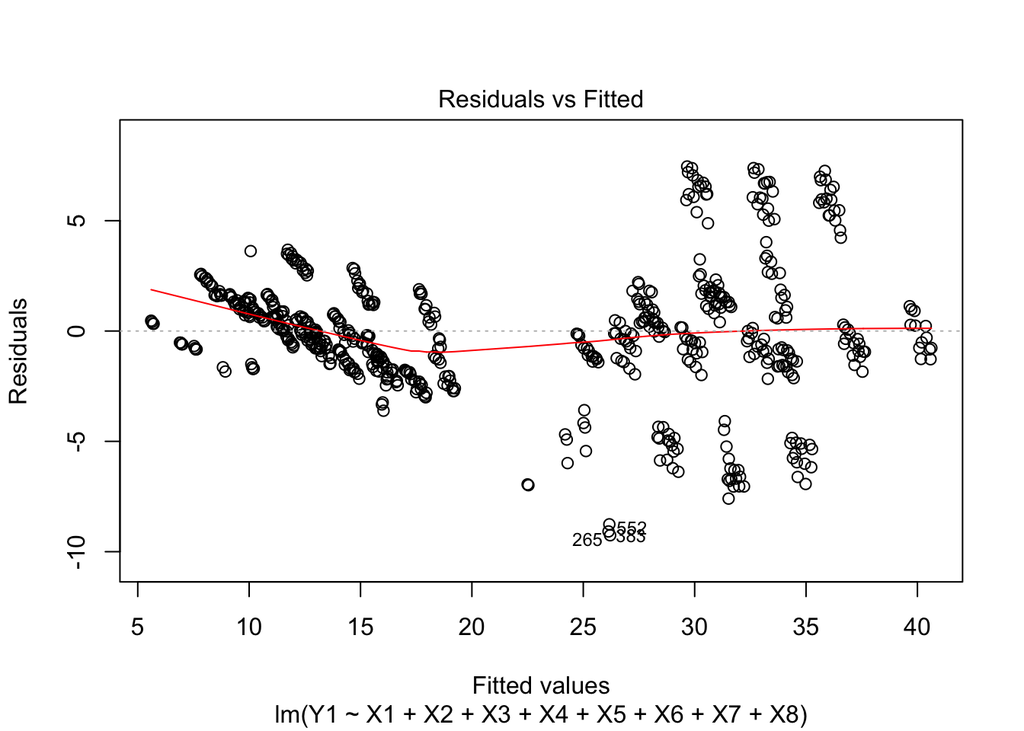

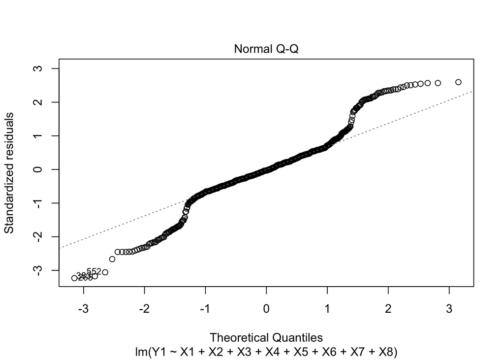

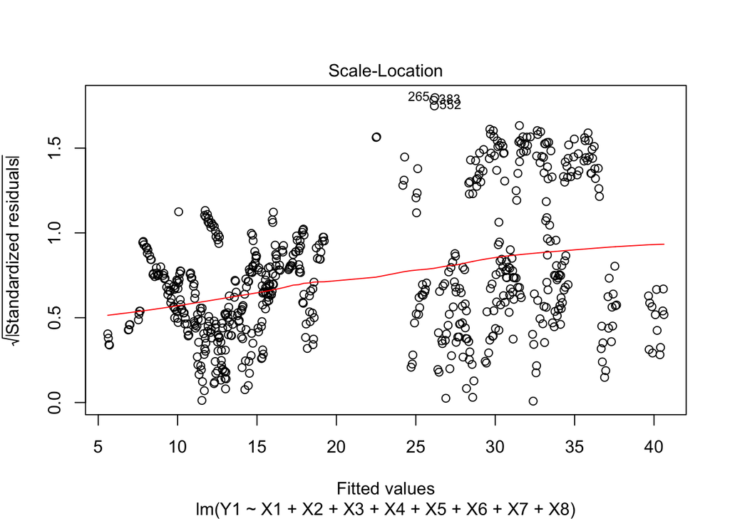

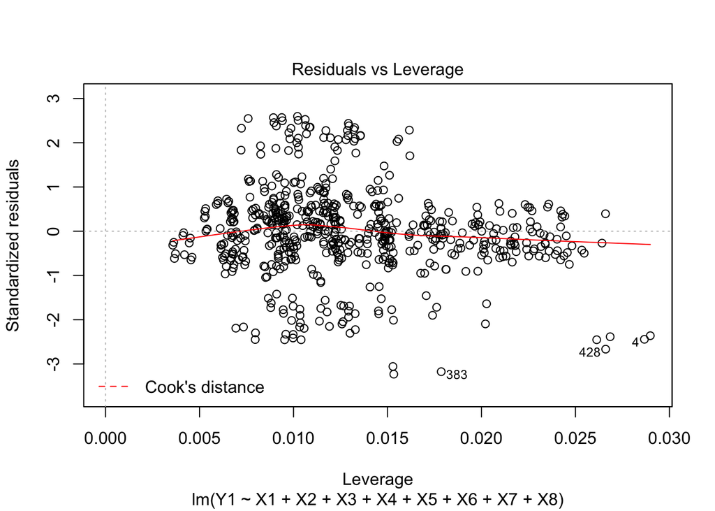

```r
plot(mod_1)
```

# 5) New features creation:

- Create new variables like Roof/Wall Area, Volume, etc.
- Do a model now. Evaluate
- New var: X4(Roof Area) * X5(Overall Height), which should be approximately the volume of the room.
- Graph comparing data(black) and prediction(red). Heating load predicted by room volume.

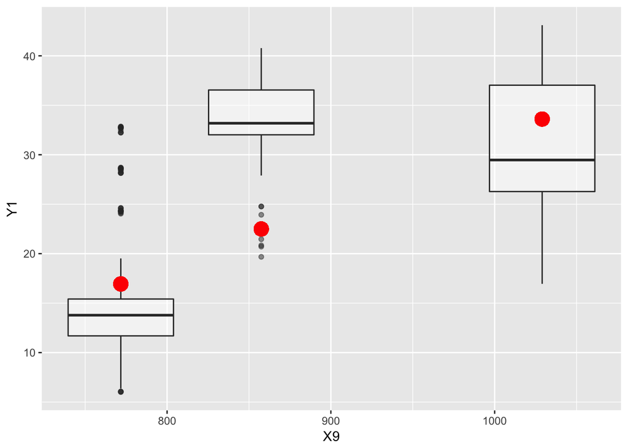

```r
b_train_vol <- b_train %>%
  mutate(X9 = X4*X5)
mod_2 <- lm(Y1 ~ X9, data = b_train_vol)

grid_3 <- b_train_vol %>%
  data_grid(b_train_vol, X9) %>%
  add_predictions(mod_2, "pred_Y1")

ggplot(b_train_vol, aes(x = X9, y = Y1, group = cut(X9, breaks=c(0, 800, 900)))) +
  geom_boxplot(alpha = 0.5) +
  geom_point(data = grid_3, aes(y = pred_Y1), color = "red", alpha = 0.5, size = 5)
```

```r
summary(mod_2)
```

```
##
## Call:
## lm(formula = Y1 ~ X9, data = b_train_vol)
##
## Residuals:
##     Min      1Q  Median      3Q     Max
## -16.658  -4.966  -2.342   6.245  18.283
##
## Coefficients:
##               Estimate Std. Error t value Pr(>|t|)
## (Intercept) -33.055754   2.398717  -13.78   <2e-16 ***
## X9            0.064785   0.002807   23.08   <2e-16 ***
## ---
## Signif. codes:  0 '***' 0.001 '**' 0.01 '*' 0.05 '.' 0.1 ' ' 1
##
## Residual standard error: 7.439 on 612 degrees of freedom
## Multiple R-squared:  0.4654, Adjusted R-squared:  0.4645
## F-statistic: 532.7 on 1 and 612 DF,  p-value: < 2.2e-16
```

- The variable is statistically significant(***), but there’s a low r square(~0.4). We can also see from the graph that the prediction for heating load is higher than reality for two groups on the side but very low for the middle group. The prediction is not reliable.

# 6) Interpretation:

- If you increase each of 3 the most important parameters by 1 unit, how much heating load is increasing?

```r
summary(mod_1)
```

```
##
## Call:
## lm(formula = Y1 ~ X1 + X2 + X3 + X4 + X5 + X6 + X7 + X8, data = b_train)
##
## Residuals:
##     Min      1Q  Median      3Q     Max
## -9.2557 -1.3478 -0.0919  1.3161  7.4560
##
## Coefficients: (1 not defined because of singularities)
##               Estimate Std. Error t value Pr(>|t|)
## (Intercept)  82.337849  21.245150   3.876 0.000118 ***
## X1          -65.497565  11.563028  -5.664 2.28e-08 ***
## X2           -0.084015   0.019060  -4.408 1.23e-05 ***
## X3            0.056549   0.007476   7.564 1.46e-13 ***
## X4                  NA         NA      NA       NA
## X5            4.411017   0.376760  11.708  < 2e-16 ***
## X6            0.036830   0.104395   0.353 0.724363
## X7           19.882442   0.900243  22.086  < 2e-16 ***
## X8            0.214952   0.076680   2.803 0.005222 **
## ---
## Signif. codes:  0 '***' 0.001 '**' 0.01 '*' 0.05 '.' 0.1 ' ' 1
##
## Residual standard error: 2.887 on 606 degrees of freedom
## Multiple R-squared:  0.9203, Adjusted R-squared:  0.9194
## F-statistic: 999.4 on 7 and 606 DF,  p-value: < 2.2e-16
```

# 7) Test:

```r
pre <- b_test %>%
  add_predictions(mod_1, "pred_Y1") %>%
  mutate(res = Y1 - pred_Y1)
```

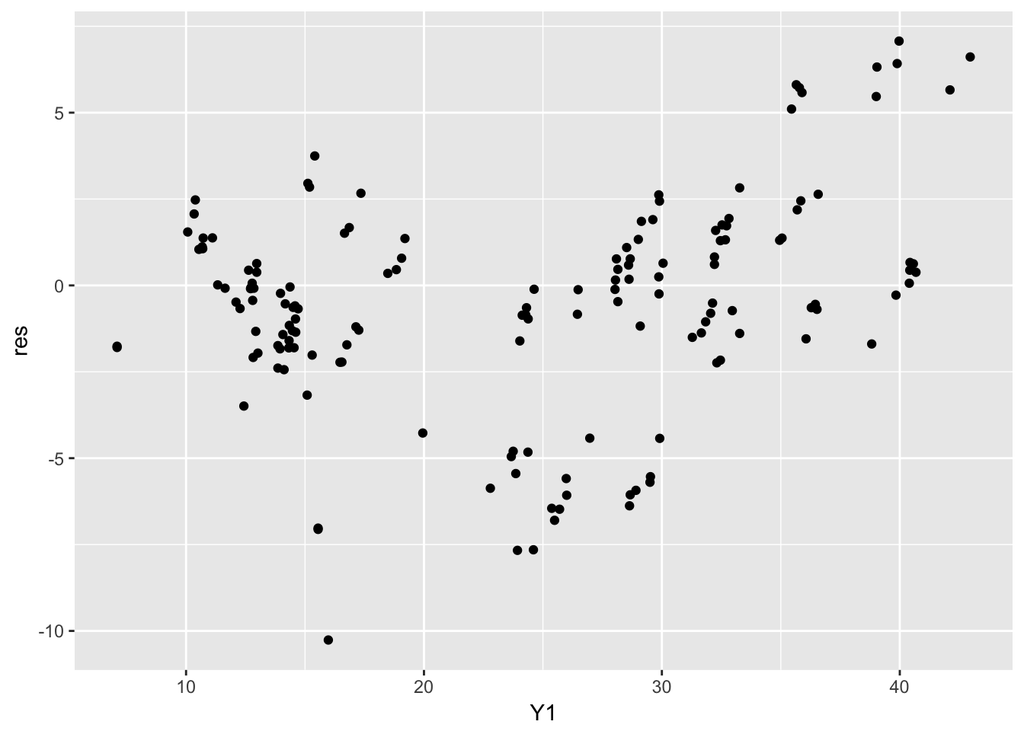

```r
ggplot(data = pre, aes(x = Y1, y = res)) +
  geom_point()
```

You may consider to calculate R2 between predicted and actual values (manual coding of steps to obtain R2 may be needed in this case). Ok I don’t have time to do this…